# Personal Electronics Overview

# Summary

1. Human Machine Interface (HMI) by using hand and finger gestures in Smart Watches, Fitness equipment, Earbuds, Wireless Speakers, and more
2. Vital Signs monitoring such as heart rate and breathing rate in TVs, Notebook PC, and Bedside monitors
3. Presence detection, tracking, and classification for human vs non-human motion for personal and consumer electronics equipment. Onlooker presence detection for Notebook PC security applications

[figure not shown]

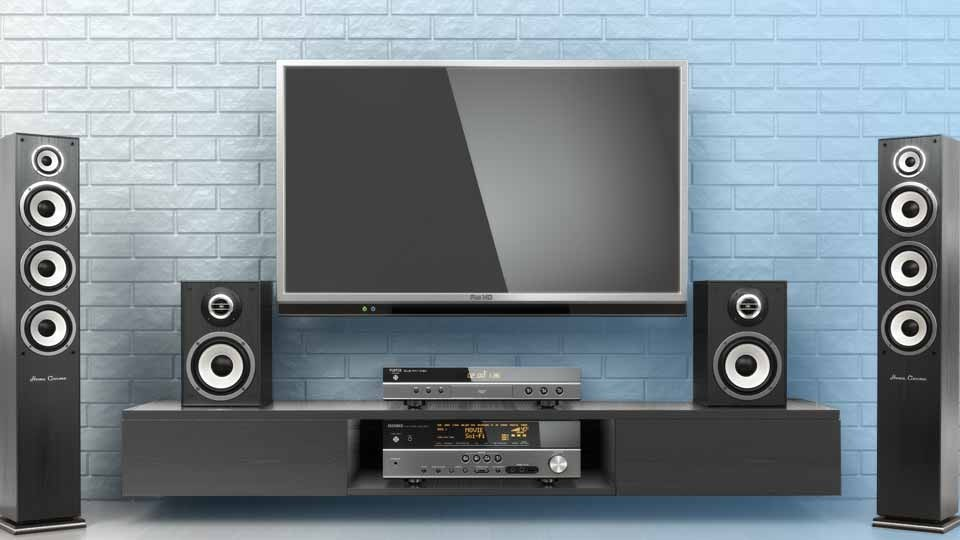

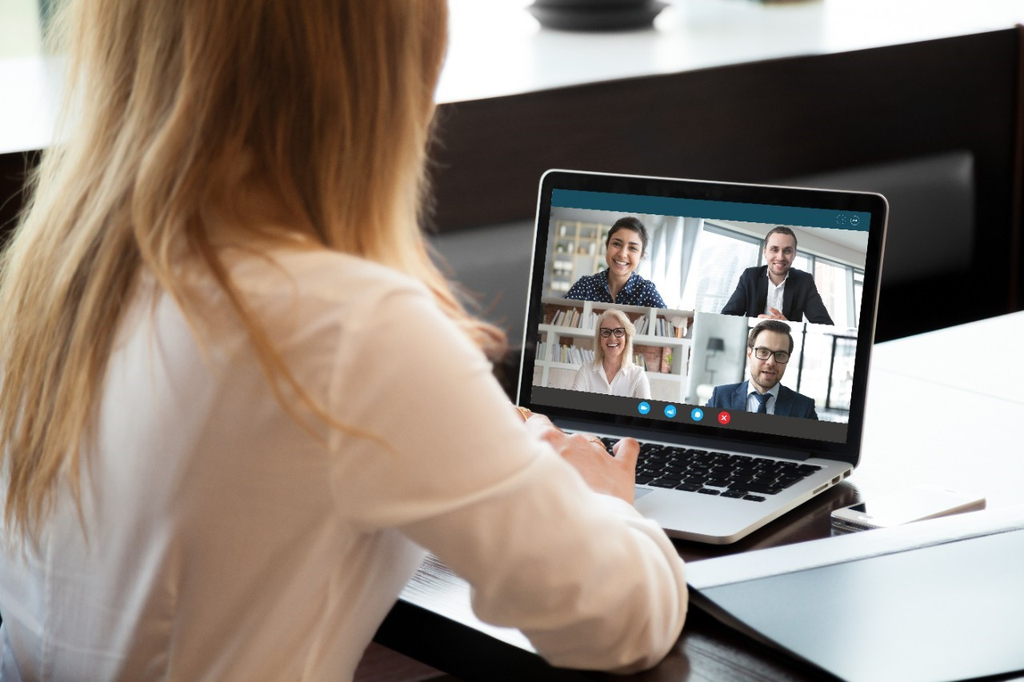

**Wearables**

**Entertainment Systems and Bedside Monitors**

**Handheld Electronics and Conferencing Systems**

Recommended Devices:  
IWR6843  
IWRL6432

Recommended Devices:  
IWR6843  
IWRL6432

Recommended Devices:  
IWRL6432

## Wearables

| Recommended devices | Key Functions | Key challenges overcome by radar |
| --- | --- | --- |
| IWR6843 IWR6843AOP IWRL6432 | - Hand Gestures - Finger Rotation Gestures - Presence detection - Motion detection - Velocity detection - Fall detection - Localization | - Interface for small devices - Direction of motion - Detection in darkness, bright light - Detection in precipitation (rain, snow, fog) - Multi-zone detection |

### Development Resources

**Example Projects**

- Out of Box Demo (presence and motion detection)
- Gesture Recognition(IWR6843ODS, IWR6843AOP)

**Experiments**

- Very Fine Motion Detection Vs PIR
- Detecting Gesture Motions Through Smoke or Glass

## Entertainment Systems and Bedside Monitors

| Recommended devices | Key Functions | Key challenges overcome by radar |
| --- | --- | --- |
| IWR6843 IWR6843AOP IWRL6432 | - Heart rate monitor - Breathing rate monitor - Presence detection - Motion detection - People counting - Static object detection - Human vs non-human classification - Velocity detection | - Vital signs monitoring - Sleep Monitoring - False detection - Static Detection - Direction of motion - People counting - Classification |

### Development Resources

**Example Projects**

- Out of Box Demo (presence and motion detection)
- Gesture Recognition(IWR6843ODS, IWR6843AOP)
- 3D People Counting (IWR6843ISK, IWR6843ODS, IWR6843AOP, or IWR6843L)
- Vital Signs with People Tracking (IWR6843AOP, IWR6843ISK)
- Indoor Occupancy Monitoring(IWRL6432BOOST)

**Experiments**

- Very Fine Motion Detection Vs PIR
- Detecting Walls of Different Materials
- Fall Detection
- Zone Occupancy Detection

## Handheld Electronics and Conferencing Systems

| Recommended devices | Key Functions | Key challenges overcome by radar |
| --- | --- | --- |
| IWRL6432 | - Onlooker Presence - Presence detection - Motion detection - People counting/tracking - Human vs non-human classification - Fall detection - Space occupancy - Localization | - False detection - Fine motion detection - Localization - People Counting/Tracking - Fall detection - Static detection |

### Development Resources

**Example Projects**

- Out of Box Demo (presence and motion detection)
- Gesture Recognition(IWR6843ODS, IWR6843AOP)
- 3D People Counting (IWR6843ISK, IWR6843ODS, IWR6843AOP, or IWR6843L)
- Vital Signs with People Tracking (IWR6843AOP, IWR6843ISK)
- Indoor Occupancy Monitoring(IWRL6432BOOST)
- Onlooker Detection(IWRL6432BOOST)

**Experiments**

- Very Fine Motion Detection Vs PIR
- Zone Occupancy Detection
- Detecting Gesture Motions Through Smoke or Glass

## Certification

- [TI mmWave Radar Device Regulatory Compliance Guide](http://www.ti.com/lit/spracp3)
- TI mmWave Certification Database

## Third Party Resources

- [Designing TI mmWave radar made easier using our third-party ecosystem](https://e2e.ti.com/blogs_/b/industrial_strength/posts/ti-mmwave-radar-made-easy-with-our-third-party-ecosystem)
- [Browse third-party solutions and find the right third-party to meet your needs](https://www.ti.com/tool/MMWAVE-3P-SEARCH)